# Bayesian Analysis in R using High Level Stan Libraries

BioData Club

Jose Laborde PhD

10/16/2020

# An elevator summary of Bayesian Analysis

- More than one way to do a statistical analysis.
- Usually the parameters to be estimated are considered fixed but unknown numbers (like the betas in regression)
- In the usual “frequentist” way, these betas are then estimated and those estimations are tested with some significance level (p-values and all).
- Although there are interval estimations the estimators themselves along with the inference performed on them have to have a weird assumption of “if we could repeat this sampling process 100 times, we would see that 5% of time the estimation would differ from the hypothesis”
- In Bayesian analysis the parameters are not considered fixed numbers. Instead these are considered random variables and so the end result of the analysis is an estimation of the entire distribution of the parameters of interest.
- Once we have a distribution at hand, one can compute any statistic we want from it e.g. histograms, intervals, medians, modes, quantiles, etc.
- The inference that comes along a Bayesian analysis is therefore intuitive and does not have to assume anything about samples we never took.

## The tricky but fun part: Bayes Theorem

$$p(\theta|D) = \frac{p(D|\theta)p(\theta)}{p(D)}$$
where:

- $\theta$: parameter(s) of the model.
- $D$: is the data (usually $X_1, X_2, \dots, X_n$)
- $p(\theta|D)$: posterior distribution of the parameter(s)
- $p(D|\theta)$: Likelihood function (Yes, the same one as in the frequentist analysis)
- $p(\theta)$: prior distribution of the parameter(s) (Here we store any previous knowledge of the parameters)
- $p(D)$: normalizing constant (the integral of the numerator is the marginal distribution of $D$).

## The packages we will need

### Essential for this talk:

- `RStan` https://mc-stan.org/users/interfaces/rstan
- `RStanArm`https://mc-stan.org/users/interfaces/rstanarm
- `bayestestR` https://easystats.github.io/bayestestR/index.html
- `bayesplot` https://mc-stan.org/users/interfaces/bayesplot

### Other alternatives

- `BayesFactor` https://richarddmorey.github.io/BayesFactor/
- `brms` https://paul-buerkner.github.io/brms/

### What we will learn:

- Use `RStanArm`’s functionality to model a multiple regression using `stan_glm`.
- Use `bayestestR` to look at the inference results.
- Use `bayesplot` to visualize the estimation’s results.

### What we won’t discuss:

- Prior distributions in depth. We will stick to default priors (weakly informative priors based on their scale). Keep in mind that these are usually the best choices when we lack historic information on parameters.
- How to build a model from first principles using `Stan` only. This type of modeling is required when we wish to do a non standard statistical analysis or a custom inference for very specific reasons. Most of the time, if we need to to LMs, GLMs, and so forth, we should be good with `RStanArm`.
- We won’t go in depth with model diagnostics here. That is an extensive topic on its own.

# The usual frequentist model:

For the multiple linear regression model
$$y = \alpha + \beta_1x_1 + \dots + \beta_kx_k + \epsilon$$
we typically assume a Gaussian Likelihood and fixed unknown parameters:
$$y \sim N(\mu, \sigma^2)$$
with $\mu = \alpha + \beta_1x_1 + \dots + \beta_kx_k$, $\epsilon \sim N(0,\sigma^2)$, $\beta_1, \dots \beta_k$ fixed but unknown. The statistical problem is then to estimate the value of the $\beta_i$s. This is usually done via maximum likelihood and `R` has the `lm` function just for that.

```r
data("mtcars")
head(mtcars)
```

|  | mpg | cyl | disp | hp | drat | wt | qsec | vs | am | gear | carb |
| --- | --- | --- | --- | --- | --- | --- | --- | --- | --- | --- | --- |
| Mazda RX4 | 21.0 | 6 | 160 | 110 | 3.90 | 2.620 | 16.46 | 0 | 1 | 4 | 4 |
| Mazda RX4 Wag | 21.0 | 6 | 160 | 110 | 3.90 | 2.875 | 17.02 | 0 | 1 | 4 | 4 |
| Datsun 710 | 22.8 | 4 | 108 | 93 | 3.85 | 2.320 | 18.61 | 1 | 1 | 4 | 1 |
| Hornet 4 Drive | 21.4 | 6 | 258 | 110 | 3.08 | 3.215 | 19.44 | 1 | 0 | 3 | 1 |
| Hornet Sportabout | 18.7 | 8 | 360 | 175 | 3.15 | 3.440 | 17.02 | 0 | 0 | 3 | 2 |
| Valiant | 18.1 | 6 | 225 | 105 | 2.76 | 3.460 | 20.22 | 1 | 0 | 3 | 1 |

```r
mpgFormula = as.formula(mpg ~ cyl
                            + hp
                            + drat
                            + wt
                            + qsec
                            + gear
                            + carb)
freqModel = lm(mpgFormula, data = mtcars)
summary(freqModel)
```

```
##
## Call:
## lm(formula = mpgFormula, data = mtcars)
##
## Residuals:
##     Min      1Q  Median      3Q     Max
## -3.1386 -1.6337 -0.3204  1.2226  5.2863
##
## Coefficients:
##             Estimate Std. Error t value Pr(>|t|)
## (Intercept) 18.23738   17.64262   1.034   0.3116
## cyl         -0.18563    0.89697  -0.207   0.8378
## hp          -0.01292    0.01753  -0.737   0.4682
## drat         1.23506    1.57241   0.785   0.4399
## wt          -2.84200    1.13636  -2.501   0.0196 *
## qsec         0.37043    0.57055   0.649   0.5223
## gear         1.31217    1.38484   0.948   0.3528
## carb        -0.65825    0.59831  -1.100   0.2822
## ---
## Signif. codes:  0 '***' 0.001 '**' 0.01 '*' 0.05 '.' 0.1 ' ' 1
##
## Residual standard error: 2.597 on 24 degrees of freedom
## Multiple R-squared:  0.8563, Adjusted R-squared:  0.8144
## F-statistic: 20.43 on 7 and 24 DF,  p-value: 1.146e-08
```

```r
confint(freqModel)
```

```
##                    2.5 %      97.5 %
## (Intercept) -18.17519667 54.64994807
## cyl          -2.03689630  1.66563292
## hp           -0.04910781  0.02326082
## drat         -2.01022438  4.48034512
## wt           -5.18732038 -0.49667644
## qsec         -0.80712154  1.54798145
## gear         -1.54598721  4.17033191
## carb         -1.89311083  0.57660353
```

We see from this model the only “significant” parameter is $\hat{\beta}_{wt}$ (assuming a significance level of 5%). From the usual hypothesis testing procedure we would need to say that "if we took 100 different samples, 95 of those would show us that $\beta_{wt}$s estimate should show a p-value smaller than the significance level (or a the confidence interval would not contain zero 95 out of 100 times). We are all used to that concept. However why are we making a conclusion based on samples we never took? This is weird.

We are all very used the convenience and ease of use of the `lm` function and other similar ones (`glm`, `lmer`, etc.) which have similar syntax by having a formula and a dataset as the 2 main parameters and maybe also a link function (in the case of `glm` with a gaussian link this is exactly the same as an `lm`).

# The bayesian model:

In the bayesian framework we also have a likelihood function linking the model parameters with the data, however here the model parameters themselves are not fixed constants but random variables instead. The estimation problem becomes one of an entire distribution rather than a point. We have:
$$y \sim N(\alpha + \beta_1x_1 + \dots + \beta_kx_k, \sigma^2)$$
with
$$\alpha \sim \pi_\alpha$$
$$\beta_i \sim \pi_i, i=1, 2, \dots, k$$
$$\sigma \sim \pi_\sigma$$
where $\pi$s are prior distributions for each parameter to be estimated.

- Note: If we were to do this estimation using `RStan` alone, we would need to specify the priors above. Since we are using `RStanarm` this package takes care of this for us whenever we do not provide any priors.

```r
library(rstanarm) # stan_glm
bayesModel = stan_glm(mpgFormula, family = gaussian(), data = mtcars)
```

## Priors

Can look into some basic information on the prior distributions used.

```r
prior_summary(bayesModel)
```

```
## Priors for model 'bayesModel'
## ------
## Intercept (after predictors centered)
##   Specified prior:
##     ~ normal(location = 20, scale = 2.5)
##   Adjusted prior:
##     ~ normal(location = 20, scale = 15)
##
## Coefficients
##   Specified prior:
##     ~ normal(location = [0,0,0,...], scale = [2.5,2.5,2.5,...])
##   Adjusted prior:
##     ~ normal(location = [0,0,0,...], scale = [ 8.44, 0.22,28.18,...])
##
## Auxiliary (sigma)
##   Specified prior:
##     ~ exponential(rate = 1)
##   Adjusted prior:
##     ~ exponential(rate = 0.17)
## ------
## See help('prior_summary.stanreg') for more details
```

- Note: for more details on default prior check this: https://mc-stan.org/rstanarm/articles/priors

## Look at the summary of results:

`rstanarm` has it’s own overloaded `summary` function. I will just make it a little bit more aesthetic:

```r
library(dplyr) # To use 'slice' and 'n'
library(kableExtra) # To use 'kable' and the likes
bs1 = summary(bayesModel, digits = 2, prob=c(.025, .5, .975))
bs1 = as.data.frame(bs1)
bs1 = round(bs1,3)
# This will cut out the mean_PPD and the log-posterior rows (the last 2) from the summary
bs1 = slice(bs1, 1:(n()-2))
# Change the column name
kable(bs1, 'html', booktabs = TRUE, linesep = '', caption = 'Bayesian Regression Model Results for MPG with 95% Credible Intervals')%>%
  kable_styling(font_size = 15.0)%>%
  footnote(number = c('MCSE = Monte Carlo Standard Error'))
```

Bayesian Regression Model Results for MPG with 95% Credible Intervals

|  | mean | mcse | sd | 2.5% | 50% | 97.5% | n_eff | Rhat |
| --- | --- | --- | --- | --- | --- | --- | --- | --- |
| (Intercept) | 18.235 | 0.347 | 18.832 | -18.130 | 18.059 | 55.267 | 2940 | 1.000 |
| cyl | -0.182 | 0.018 | 0.967 | -2.081 | -0.194 | 1.743 | 2911 | 1.000 |
| hp | -0.013 | 0.000 | 0.019 | -0.050 | -0.012 | 0.025 | 3793 | 1.000 |
| drat | 1.229 | 0.029 | 1.695 | -2.154 | 1.243 | 4.570 | 3377 | 1.000 |
| wt | -2.836 | 0.020 | 1.201 | -5.169 | -2.817 | -0.537 | 3474 | 1.000 |
| qsec | 0.364 | 0.011 | 0.624 | -0.899 | 0.362 | 1.580 | 3140 | 1.000 |
| gear | 1.340 | 0.027 | 1.452 | -1.519 | 1.314 | 4.252 | 2898 | 1.000 |
| carb | -0.676 | 0.012 | 0.629 | -1.920 | -0.687 | 0.617 | 2986 | 1.000 |
| sigma | 2.728 | 0.009 | 0.420 | 2.069 | 2.679 | 3.710 | 2404 | 1.003 |

<sup>1</sup> MCSE = Monte Carlo Standard Error

- Note: for the MCSE check this: https://jrnold.github.io/bayesian_notes/mcmc-diagnostics.html
- Monte Carlo Standard Error “provides a quantitative suggestion of how big the estimation noise is” by estimating the noise in the chains.

## Look at the tests for this model

So how about some sort of Hypothesis testing? Let’s use `bayestestR` for that.

```r
library(bayestestR) # describe_posterior
bayesModel_posterior = as.matrix(bayesModel)
bayesModel_Test = describe_posterior(bayesModel)
# This will make the rownames as the first column in the data frame
rownames(bayesModel_Test) = bayesModel_Test[,1]
# This will remove the first column since the rownames are already stored
bayesModel_Test = bayesModel_Test[,-1]
bayesModel_Test = round(bayesModel_Test,3)
kable(bayesModel_Test, 'html', booktabs = TRUE, linesep = '', caption = 'Tests for Bayesian Regression Model Results for MPG')%>%
  kable_styling(font_size = 15.0)%>%
  footnote(number = c('ROPE = region of practical equivalence'))
```

Tests for Bayesian Regression Model Results for MPG

|  | Median | CI | CI_low | CI_high | pd | ROPE_CI | ROPE_low | ROPE_high | ROPE_Percentage | Rhat | ESS |
| --- | --- | --- | --- | --- | --- | --- | --- | --- | --- | --- | --- |
| (Intercept) | 18.059 | 89 | -11.523 | 47.701 | 0.840 | 89 | -0.603 | 0.603 | 0.017 | 1 | 2939.708 |
| cyl | -0.194 | 89 | -1.678 | 1.359 | 0.584 | 89 | -0.603 | 0.603 | 0.526 | 1 | 2911.098 |
| hp | -0.012 | 89 | -0.042 | 0.018 | 0.754 | 89 | -0.603 | 0.603 | 1.000 | 1 | 3792.599 |
| drat | 1.243 | 89 | -1.340 | 4.053 | 0.763 | 89 | -0.603 | 0.603 | 0.256 | 1 | 3377.061 |
| wt | -2.817 | 89 | -4.738 | -0.950 | 0.990 | 89 | -0.603 | 0.603 | 0.000 | 1 | 3473.689 |
| qsec | 0.362 | 89 | -0.606 | 1.353 | 0.731 | 89 | -0.603 | 0.603 | 0.657 | 1 | 3139.681 |
| gear | 1.314 | 89 | -0.868 | 3.786 | 0.826 | 89 | -0.603 | 0.603 | 0.240 | 1 | 2898.182 |
| carb | -0.687 | 89 | -1.720 | 0.267 | 0.864 | 89 | -0.603 | 0.603 | 0.433 | 1 | 2985.735 |

<sup>1</sup> ROPE = region of practical equivalence

- So what is the ROPE? check this: https://easystats.github.io/bayestestR/articles/region_of_practical_equivalence.html
- In essence, it is a null region (an interval around zero) tested against the parameter’s estimated distribution. If they overlap more than just a little bit, then you accept the Null. Yes. Accept.
- For linear models (lm), the ROPE is:
  $$[−0.1∗SD_y, 0.1∗SD_y]$$
- We see that the end result is that the ROPE percentage is consistent with the frequentist conclusion with respect to the `wt` variable.

There are other interesting results we can show:

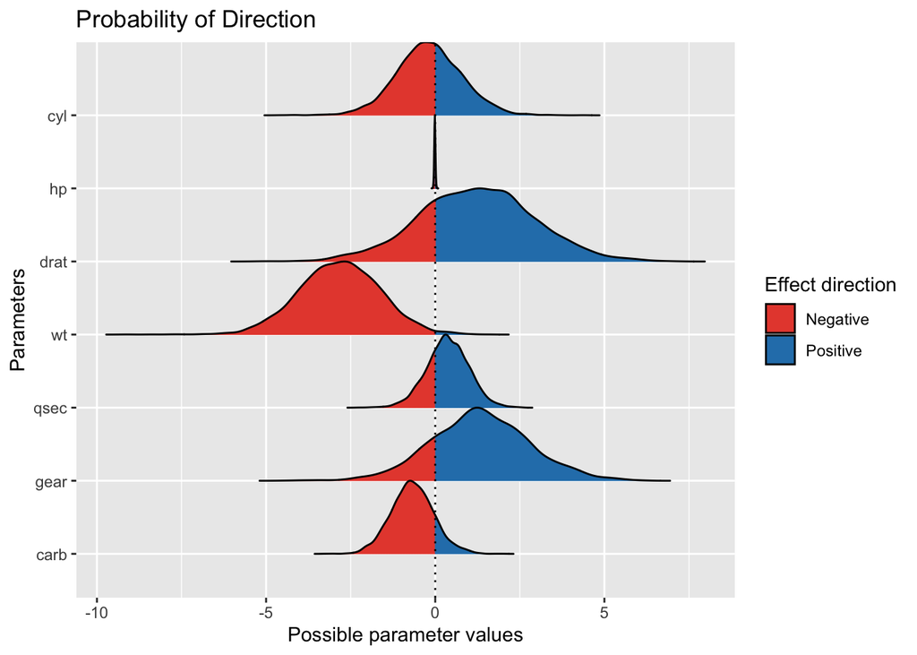

```r
# Compute indices
pd = p_direction(bayesModel)
percentage_in_rope = rope(bayesModel, ci=1)
# ci: The Credible Interval (CI) probability, corresponding to the proportion of HDI, to use for the percentage in ROPE.
# HDI: Highest Density Interval

# Visualize the pd (Probability of Direction)
plot(pd)
```

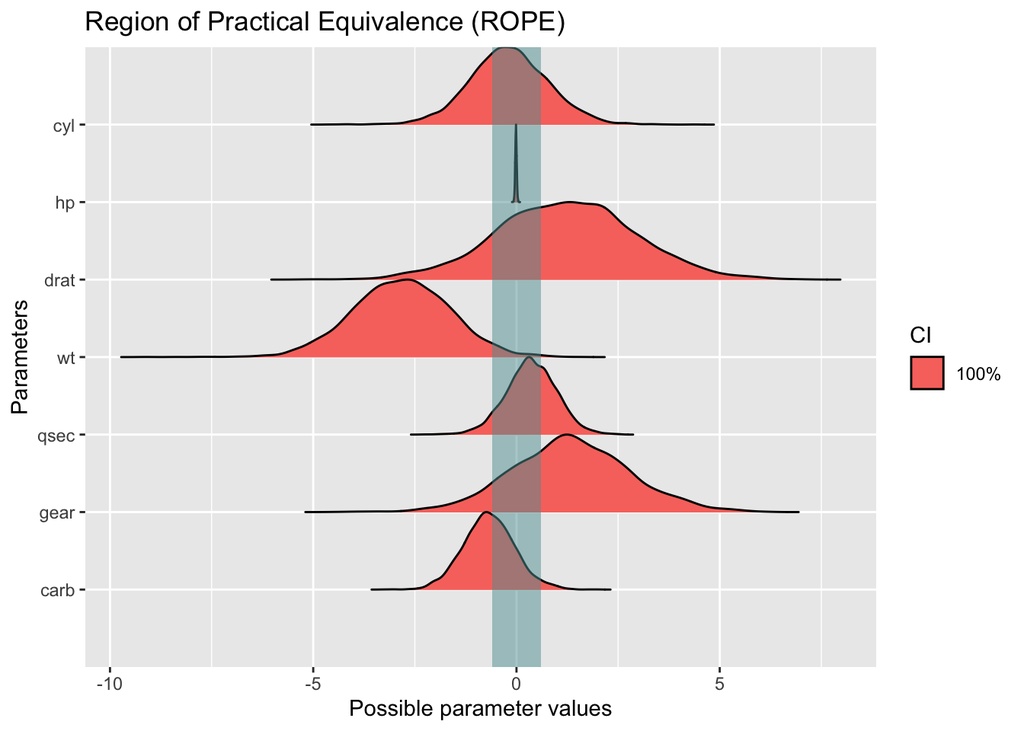

```r
# Visualize the percentage in ROPE
plot(percentage_in_rope)
```

## Look at the plot of results:

### Using the `plot` function

`rstanarm` also has it’s own overloaded `plot` function. It will the credible intervals:

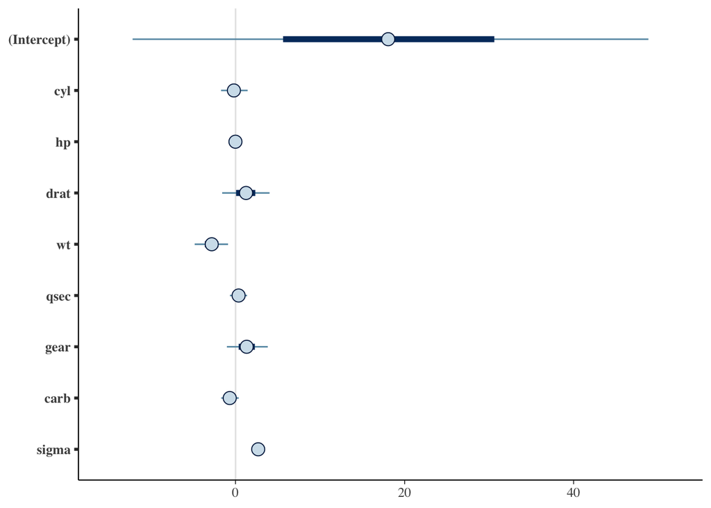

```r
plot(bayesModel)
```

### Another plotting tool: `bayesplot`

We could use `bayesplot` instead to visualize the results as densities or CIs:

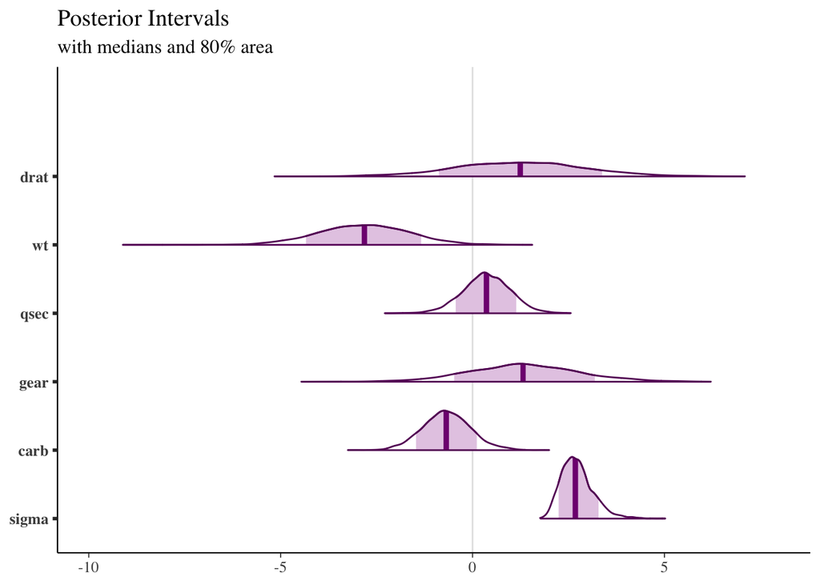

```r
library(bayesplot)
library(ggplot2)
color_scheme_set("purple")
plot_title = ggtitle("Posterior Intervals",
                     "with medians and 80% area")
mcmc_areas(bayesModel_posterior,
               pars = colnames(bayesModel_posterior[,4:9]),
               prob = 0.80) + plot_title
```

We can Also look at a basic diagnostic plot called “trace plot” which let’s us visualize the MCMC chains.

[output not shown]

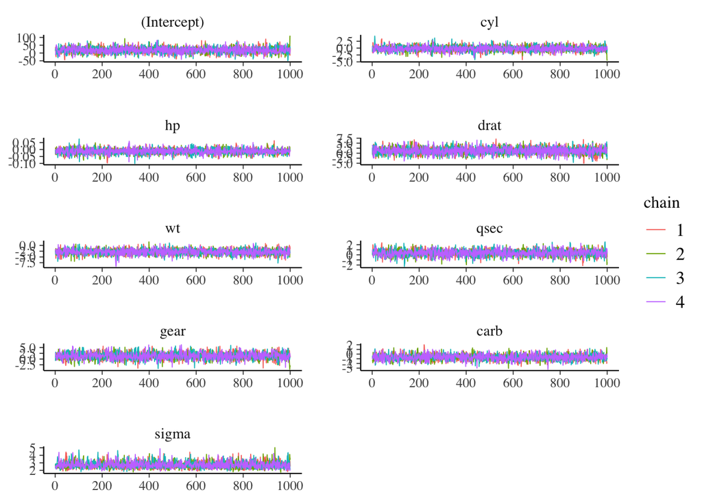

```r
x = as.array(bayesModel, pars = colnames(bayesModel_posterior))
mcmc_trace(x, facet_args = list(nrow = 5)) + ggplot2::scale_color_discrete()
```

- What about some sort of $R^2$? Check this for reference: http://www.stat.columbia.edu/~gelman/research/unpublished/bayes_R2.pdf